# Shiny Manual

This Shiny App contains functions to perform an **exploration** and a **preliminary analysis** on the **dose-response relationship** of nanomaterial toxicity. Several functions are provided for data exploration, including functions for creating a subset of dataset, frequency tables and plots. Inference for order restricted dose-response data is performed by testing the significance of monotonic dose-response relationship, using Williams, Marcus, M, Modified M and Likelihood ratio tests. Several methods of multiplicity adjustment are also provided.

## 1. Upload Data

Data can be uploaded in the **Upload Data** menu, by clicking `BROWSE`. The uploaded data should be in a tab separated value format. An example below is the `Example 2` data from menu `EXAMPLES`. The data can be downloaded using download button in the menu.

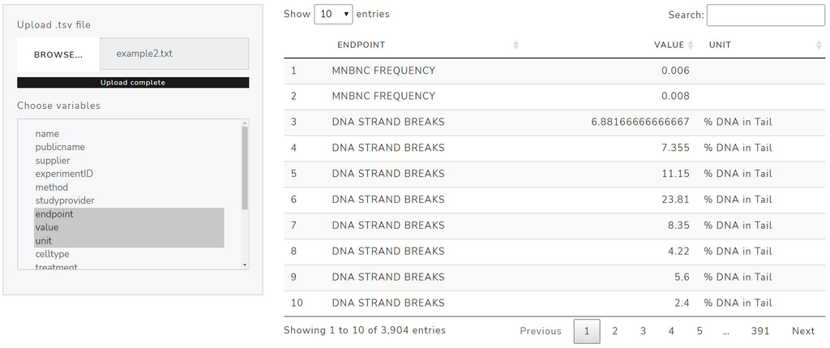

Figure 1: Upload data

Figure 1 shows where the data can be uploaded. In the option “Choose variables”, one or more variables(columns) can be chosen to be shown in the data preview on the right side of the page.

## 2. Data Exploration

### 2.1 Frequency tables

In the menu **Data exploration > Frequency tables**, the uploaded data can be explored. Here, we can extract a frequency table according to the variables and the options that are selected.  
In the option `x: Variable(s) to be explored`, one or more variables that are of interest can be selected. Another variable can be selected in the `cat: Variable used to group or subset the data`, to group or to subset the data. If a variable in `cat` is selected, then option `val: Specific value of cat` will appear. This option contains the unique values of chosen variable in `cat`. If a specific value of `cat` is selected, then the frequency table will only be provided for this particular value. Option `opt: Options for the result` determines what information will be shown in the output table.

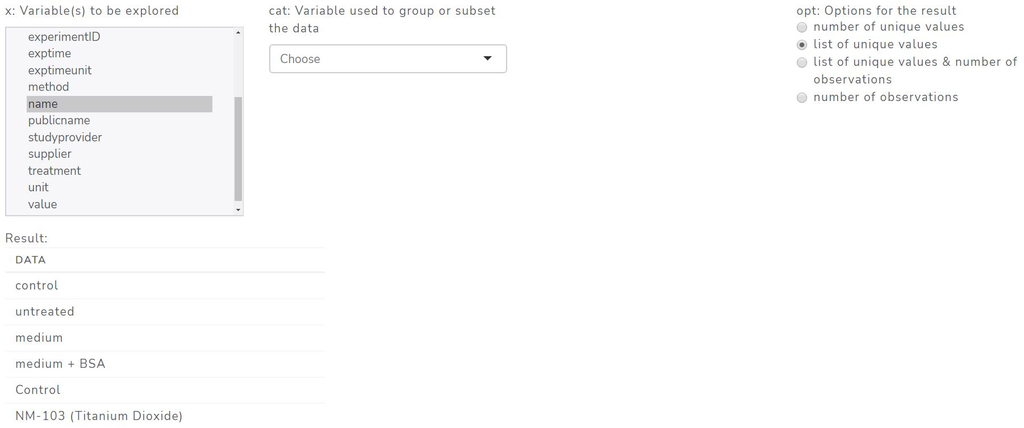

Figure 2: Explore variable name

Suppose we are interested in exploring different nanomaterials that are available in the data. As shown in figure 2, variable `name`, which contains the name of the nanomaterial, is selected in the `x:Variable(s) to be explored`. By choosing the option `list of unique values` in the `opt: Options for the result`, the list of the nanomaterials in the data will be shown.  
To explore the endpoints measured for each nanomaterial, variable `endpoint` which contains the toxicity endpoint is selected in the `x:Variable(s) to be explored` and variable `name` is selected in the `cat: Variable used to group or subset the data` as shown in figure 3. By selecting `list of unique values & number of observations` in the `opt: Options for the result`, the number of observations for each combination of name and endpoint will be shown.

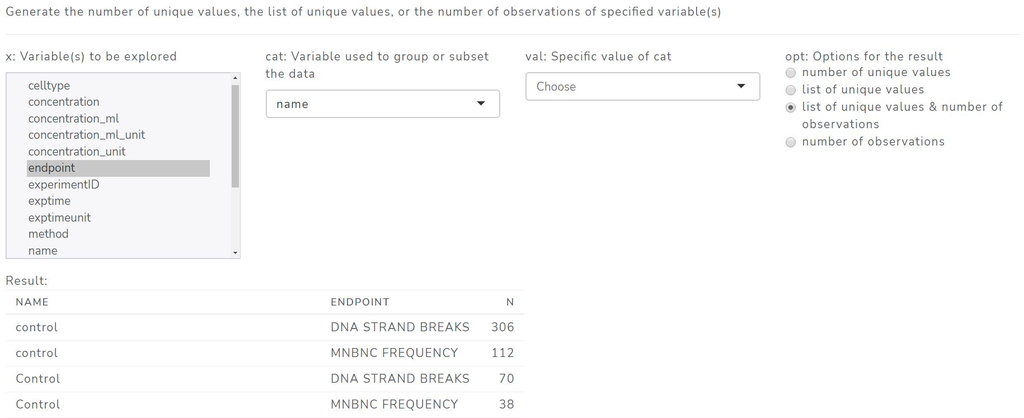

Figure 3: Explore the endpoints of each nanomaterial

More than one variables can be selected in the `x:Variable(s) to be explored`. Figure 4 shows the number of observations related to certain endpoints and concentration units for each nanomaterial. To obtain this information, variable `endpoint` and `concentration_unit` are selected in the `x:Variable(s) to be explored` and variable `name` is selected in the `cat: Variable used to group or subset the data` (to group the data). To show the number of observations for each category, `list of unique values & number of observations` is chosen in the `opt: Options for the result`.

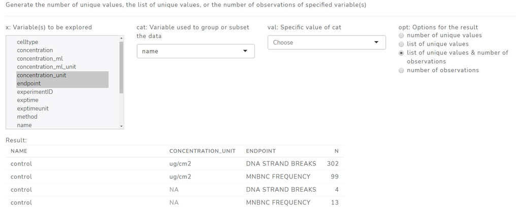

Figure 4: Explore the endpoints and the concentration units of each nanomaterial

It is also possible to explore variable(s) only for a certain value of another variable. As seen in figure 5, the result is only shown for NM-400, which is done by selecting `NM-400(Multi-walled carbon nanotubes)` in the `val: Specific value of cat`.

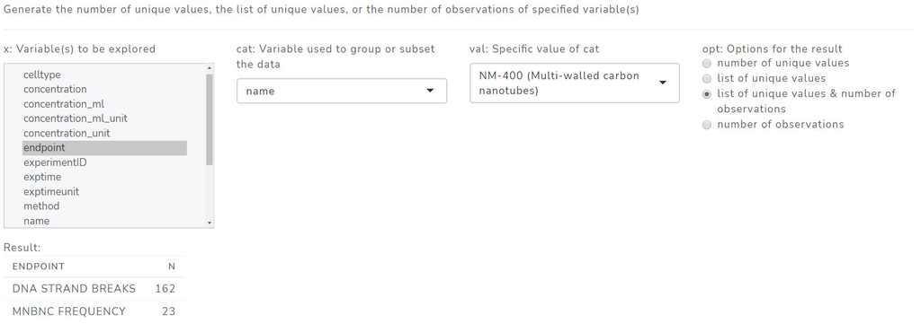

Figure 5: Explore the endpoints of NM-400

### 2.2 Controls exploration

In the menu **Data exploration > Controls exploration**, control observations can be explored. As shown in figure 6, here, we can check the name (and the number of observations) of the control observations. Variable that contains the name of the nanomaterials should be selected in the `Choose variable of nanomaterial name`, while the concentration variable should be selected in the `Choose variable of concentration`. The value that indicates the control observations (for example, concentration 0), should be selected in the `Choose concentration=0`.

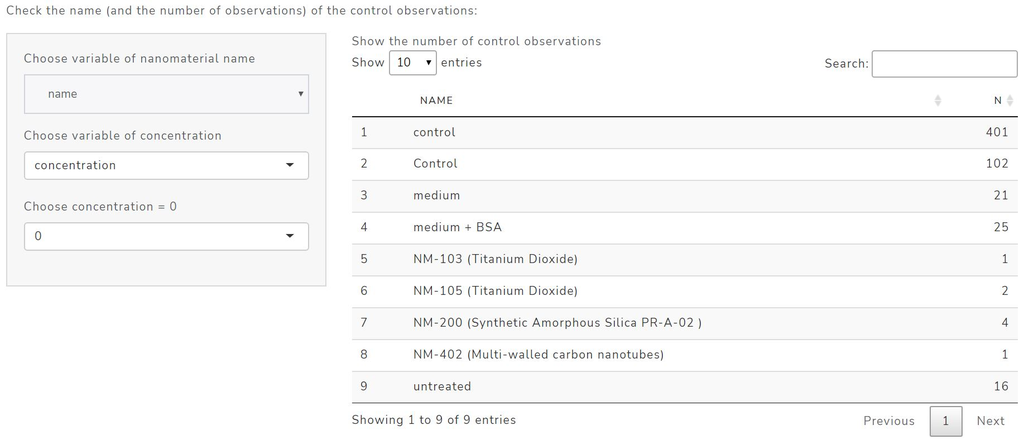

Figure 6: Explore the number of control observations in each nanomaterial

## 3. Link control & non-control observations

The plots and the tests in are created for each nanomaterial in the dataset (or for each subset of data). The different types of nanomaterials are identified by their names. Therefore, if some control values are named differently, a separate dataset, `data.control`, containing only these values first needs to be created. Controls in the new dataset can be linked to the non-control observations belonging to the same experiment through the identifier of the experiment (the linking is performed inside this function). In this situation, it is necessary to have an indicator that can identify different experiments (such as experiment ID).

Menu **Link control & non-control observations** that can be used to create `data.control` and `data.nm` to link the control and non-control observations belonging to the same experiments. Figure 7 shows the options to create the `data.control`. Variable containing the name of the nanomaterial should be chosen in the option `Choose variable of nanomaterial name` while the name(s) of the control observations should be selected in the `Choose the name of the controls`. A preview of the dataset can be seen in the right side of the window, and the data can also be downloaded.

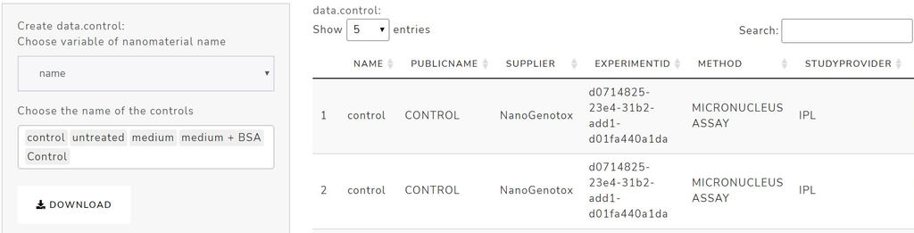

Figure 7: Create a ‘data.control’ (dataset containing control observations)

Figure 8 shows the options to create the `data.nm`, a dataset without control observations which are named differently. In the `Choose the name(s) of the controls to be excluded or specific nanomaterial(s) to be included`, the names of the controls to be excluded or the names of the nanomaterial to be included should be specified. In this example, several control observations names are going to be excluded to create `data.nm`, therefore, these names are specified in the `Choose the name(s) of the controls to be excluded or-` `specific nanomaterial(s) to be included`, and `exclude the names specified above` is selected in the `Include/Exclude`.

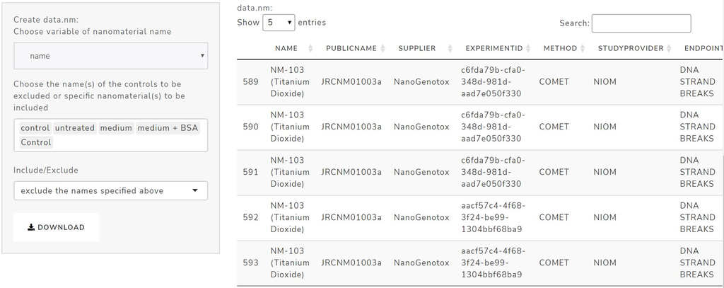

Figure 8: Create a ‘data.nm’ (dataset without control observations (with different names))

## 4. Plot and analysis

In menu **Plot and analysis**, we can generate plots of the dose and the response and perform inference. Figure 9 shows the selections that can be made related to the data, to generate the plot or to perform the inference. If all controls in the dataset are named according to the related nanomaterial names, the uploaded data can be used directly by selecting `Use the original uploaded data` in the `Select data.nm` option. Both `Select data.control` and `Choose variable of experiment identifier` do not need to be specified/selected.  
In this example, since there are control observations which are named differently, `data.nm` and `data.control` need to be created (it can be done in menu `Link control & non-control observations`). As shown in figure 9, to use this `data.nm`, `Use data.nm created in-` `'Link control & non-control observations'` and `Use data.control created in 'Link control & non-control observations'` should be chosen in the `Select data.nm` and `Select data.control` respectively. An identifier variable that can be used to link control and non-control observations belonging to the same experiment should be specified in the `Choose variable of experiment identifier`. In this case, it is variable `experimentID`.  
To generate the plot or to perform the analysis, the dataset needs to have a variable containing the name of the nanomaterial, variable response of interest and variable concentration which should be selected in the `Choose variable of nanomaterial name`, `Choose variable of` `response` and `Choose variable of dose/concentration` respectively.  
If there are several different endpoints or concentration units in the data, specific endpoint and concentration unit can be specified. Variable endpoint can be selected in `Choose variable of endpoint`, while variable concentration can be selected in `Choose variable of -` `concentration unit`. If a variable endpoint is specified, then a specific endpoint can be chosen in `Select specific endpoint`. Similarly, a specific concentration unit can be specified in `Select specific concentration unit`.  
Related to the controls, it is possible to include control observations in any unit of measurement. To do this, `include: controls with any units` should be chosen. If only controls in the specified unit of measurement are considered for the analysis, then `include: only controls with specified unit` should be selected.  
The data can also be grouped by one or more variables, which can be specified in `Choose variable(s) used to subset the data`. The plots or analysis can then be generated/performed for each subset of data.

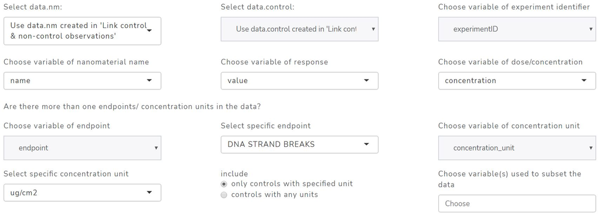

Figure 9: Variables selection

Figure 10 shows a menu `The result`, which contains options of result (plot/analysis) to be generated. To show the scatter plot of the dose and the response, `Scatter plot` can be selected. The x-axis can be the dose (`dose` in `plot:`) or the log(dose) (`log(dose)` in `plot:`). To show the result, click `RUN THE PROGRAM`.

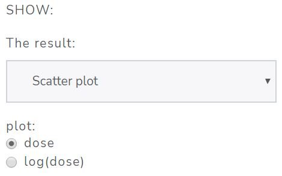

Figure 10: Scatter plot of the dose and the response

If the result is available for several different nanomaterials, the plot for a specific nanomaterial can be shown by selecting a particular nanomaterial in `Choose nanomaterial` as seen in figure 11.

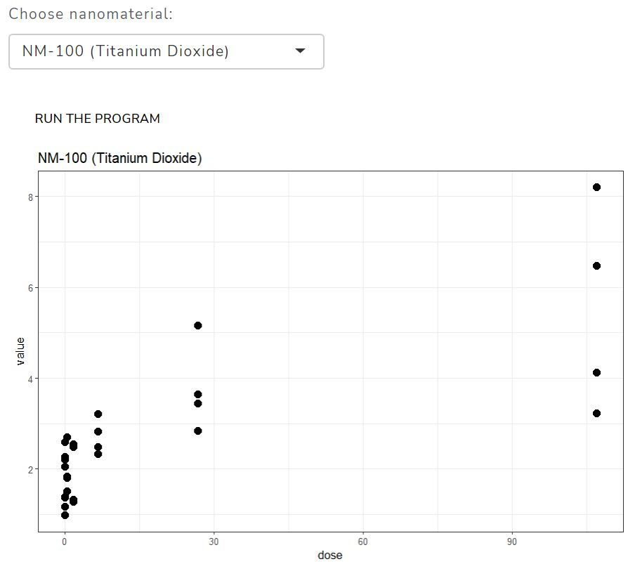

Figure 11: Scatter plot of the dose and the response

To obtain the scatter plot of the dose and the response with the isotonic means, `Isotonic means plot` should be selected in the `The result`. To show the result, click `RUN THE PROGRAM`. The result can be seen in figure 12.

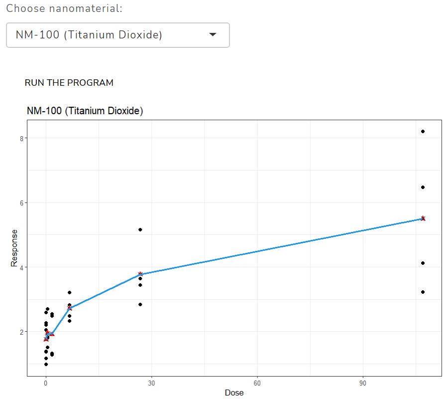

Figure 12: Plot of the isotonic means

As seen in figure 13, to perform the inference, `Trend test` should be selected in the menu `The result`. The test can be selected in `Choose the test statistics` and the method to adjust for multiplicity can be selected in the `Select a method used to adjust -` `for the multiplicity`. The seed and the number of permutations can be specified in `Specify seed:` and `Number of permutations:`, respectively. To show the result, click `RUN THE PROGRAM`

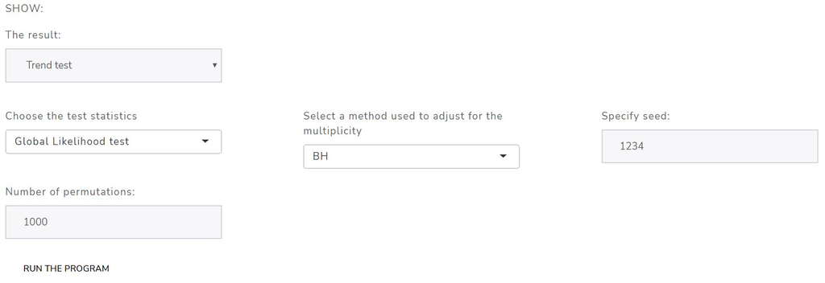

Figure 13: Trend test

Figure 14 shows the result of the trend test of the likelihood ratio test, and by applying BH method to adjust for multiplicity. Column `TSTAT.UP: E2` is the test statistic value for the “up” trend (when the response is assumed to increase as the dose increases), while column `TSTAT.DN: E2` is the test statistic for the “down” trend (when the response is assumed to decrease as the dose increases). The corresponding p-values and adjusted p-values are shown in column `PVALUE.UP`, `PVALUE.DN`, `ADJ.P.UP: BH` and `ADJ.P.DN: BH`. The more likely direction of the trend according to the likelihood can be seen in column `DIRECTION`.

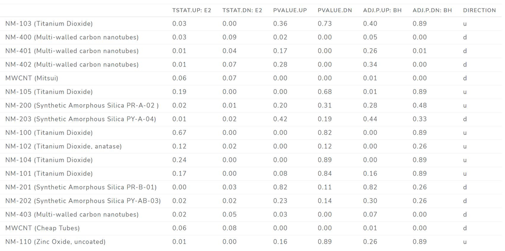

Figure 14: Result of the trend test

To generate plot of the adjusted p-values, `Adjusted p-values plot` can be selected in `The result:`. The level of the FDR can be specified in `Desired FDR level:` and the direction of trend can be selected in `Direction`, as seen in figure 15.

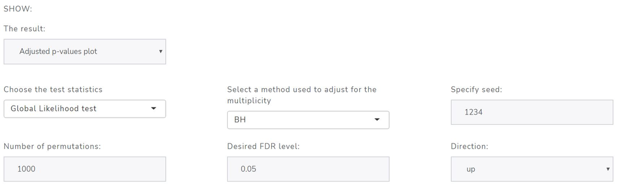

Figure 15: Generate adjusted p-values plot

Figure 16 shows the plot of the raw p-values and the adjusted p-values.

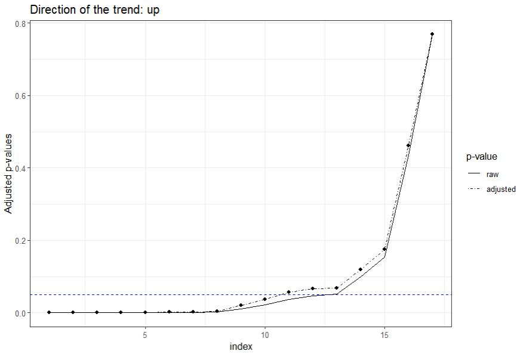

Figure 16: Adjusted p-values plot